# Section Assignment 3

1/22/25

Things-to-Note: - 1) Don’t rename external files or edit them in any way 2) Don’t change the variable names 3) Don’t destroy or overwrite any variables 4) Don’t use global path in your script. Instead use “setwd()” interactively in the console, but don’t include this code in your submission

If you don’t take above instructions into account it might effect your grades. ***

Your Information: -

```r
firstname <- "Zakir"   # example: "Liam"
lastname <- "Alibhai"  # example: "Mueller"
username <- "zalibhai"  #example: "lomueller"   Do not include the "@ucsd.edu" part!
```

Remember to add date in line 3, example: date: “04/04/2023”

If you forget to add your name or UCSD username, then you might not receive any points for this assignment ***

Please Read!

This week, your assignment is to generate one high quality figure from the heart surgery data we worked with last week. We will do this one step at a time by generating 7 figures along the way that build on each other, one line of code at a time. As this assignment builds, I want to be sure that you will catch any error you might make in an early step, so it won’t tank your entire assignment in the later, more complex code. To accomplish this, I have given you the grading rubric for this assignment. In the “Week3_SA_Grading_Rubric.pdf” you will see exactly what each of the 7 figures you will be graded on need to look like. At the end of each step, make sure the figure you create looks exactly like mine before moving on!

One of the traits of a great programmer is their ability to solve a problem they haven’t seen before. One of the best ways to solve a problem you have not seen before is to see if anyone else has. Great programmers are experts of web searching. As we are working on becoming expert programmers, this week I have included links to webpages that I used the first time I had to teach myself how to use ggplot specifically related to the question you are being asked. Copying from the internet is one of the foundations of learning how to program, but it only works as learning if you reflect on why the code you used works. For that reason, this week and in future weeks, you will need to annotate your code (Use the lines starting with a “#Note:” to explain in your own words what your code is doing. Remember the hash tag # tells R not to read a line of text and it is the way programmers leave notes for each other) You will be graded on not just your figures, but your explanation. Remember, in this class, it is okay to copy code, but you still need to demonstrate independent thought.

Answer the following question by typing the appropriate code in the code box (denoted by ``` signs).

Questions:

1. (0.5 point): The goal for this week is to generate high quality figures from the hospital data that you worked with last week. We will use the tidyverse package to accomplish this. ggplot() is part of the tidyverse family of packages. Please load up the tidyverse library in the code box below.

```r
library(tidyverse)
# The library() function loads the package to use in a new file.
```

```r
### This chunk of code is for grading purposes.
### Don't change/delete this chunk of code.
q1 <- sum((.packages())=="tidyverse")
```

2.(0.5 point): You will need to read in the data table that you created in last week’s section activity. Assign that .csv file to the “HospitalData” object on the line below. Use the file from this week’s Canvas page (“Week3Data.csv”):

```r
HospitalData <- read.csv(file = "Week3Data.csv")
head(HospitalData)
```

```
##                  Hospital Operations Survivors Deaths SurvivalRate
## 1 London - Harley Street         418       413      5    0.9880383
## 2               Leicester        607       593     14    0.9769357
## 3               Newcastle        668       653     15    0.9775449
## 4                 Glasgow        760       733     27    0.9644737
## 5             Southampton        829       815     14    0.9831122
## 6                 Bristol        835       821     14    0.9832335
```

```r
### This chunk of code is for grading purposes.
### Don't change/delete this chunk of code.
q2 <- HospitalData
```

3. (9 points over 8 steps): Generate a bar chart representing the number of child heart operations each hospital performed during the study period where the color of the bar represents the survival rate in that hospital. We will do this in a number of steps:

Step 1 (1 point). Generate the empty space that we can fill with data. In this step we will define for ggplot ONLY the data set and the x and y axes, nothing else. Please visit https://moderndive.com/2-viz.html for more information and help with getting a plot started in ggplot. It will look super messy, and that is okay, in each step it will look more and more professional. Before moving on to step 2, check that your figure 1 looks identical to the one in the associated answer key.

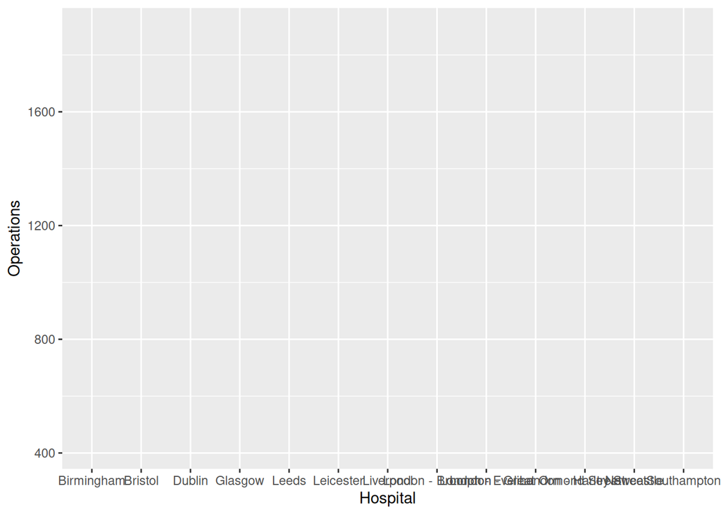

```r
fig1<- ggplot(data = HospitalData, mapping = aes(x = Hospital, y = Operations))
fig1
```

```r
#Note: Here, I'm calling the 'ggplot' function, defining the dataset as the 'HospitalData' dataframe from the previous question, setting the mapping of the x and y axes with the aesthetic function, and setting x to the 'Hospital' column and y to the 'Operations' column. This makes a visual frame for the graph with that data in the proper places.
```

```r
### This chunk of code is for grading purposes.
### Don't change/delete this chunk of code.
q3 <- fig1
```

Step 2 (1 point): Now it is time to set up the type of plot we want to visualize, by setting the geometry of the plot. In this case a bar plot. Copy your code from step 1 into the box below, then add the appropriate code on a new line. The help file from the last step will still guide you here. Again, check your results with the associated pdf and move on to step 3 if your graph is identical to mine.

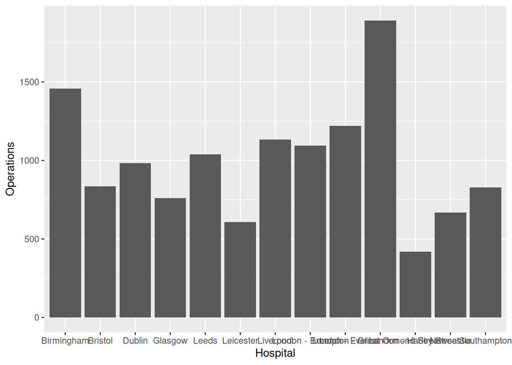

```r
fig2<-ggplot(data = HospitalData, mapping = aes(x = Hospital, y = Operations)) +
  geom_bar(stat = "identity")
#or geom_col()
fig2
```

```r
#Note: Here, I'm just adding a line to plot the geometry of the data in the format of a bar chart or column graph. ModernDrive talked about how the data in this case is "pre-counted" due to the way the categorical data in the HospitalData dataframe is formatted, so it's better to use geom_col() or make it a bar graph with identity for using the actual values instead of counting. They're (col & bar with identity) equivalent, but using bar and stat lets you customize for identity, count, etc..
```

```r
### This chunk of code is for grading purposes.
### Don't change/delete this chunk of code.
q4 <- fig2
```

step 3 (1 point): In this step we are going to reorder the bars in acceding order by the number of operations. Copy the code from step 2 into the box below and modify the code that reorders the x axis. Hint: Instead of adding a new line, this time we need to change an argument in how we assigned the X axis in the aes() argument that we first put in step 1. Check out the “sorting bars by some numeric variable” section of this link: https://sebastiansauer.github.io/ordering-bars/

Check your fig 3 with the answer key and if they look identical, move on to step 4.

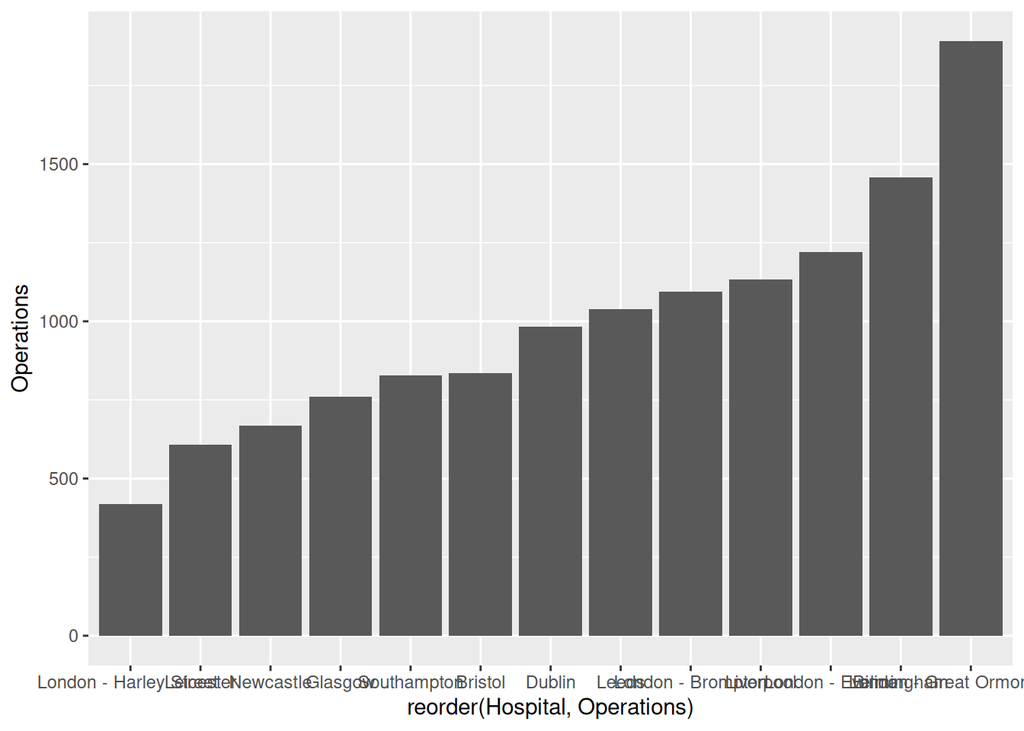

```r
fig3<- ggplot(data = HospitalData, mapping = aes(x = reorder(Hospital, Operations), y = Operations)) +
  geom_bar(stat = "identity")
fig3
```

```r
#Note: Here, I'm adding an argument to the aesthetic of x to reorder the x-axis of Hospitals by operations, and since it's acceding, it would be positive (without a minus sign). The website shows how to call the reorder function and pass in the x variable/parameter, and the second parameter is the thing you want to order by, in this case Operations, and then I just lined up the parentheses.
```

```r
### This chunk of code is for grading purposes.
### Don't change/delete this chunk of code.
q5 <- fig3
```

step 4 (1 point): Now that we have an organized plot, it is time to start working on legibility. First, we will start making changes that make it look more professional and less like an EXCEL output. The main thing making it look like an excel plot is that grey background that journals hate (to be fair, it just wastes ink). And don’t worry, we will fix that messy x axis soon, we just need to have this line happen first. The easiest way to get rid of the grey background is by changing the plot theme. Check out how to create the “theme_minimal” theme here: https://r-charts.com/ggplot2/themes/

Click on the different themes and look at what changes in the code box in this interactive online resource!

Copy your code from step 3 into the box below and add a line that modifies the theme to minimal.

Check your fig 4 with the answer key and if they look identical, move on to step 5.

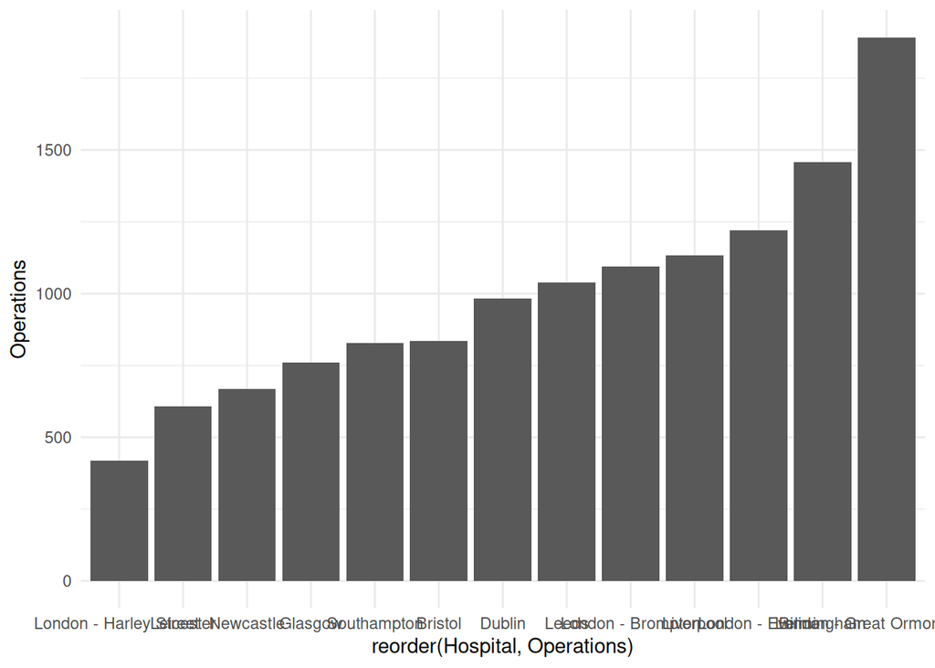

```r
fig4<-ggplot(data = HospitalData, mapping = aes(x = reorder(Hospital, Operations), y = Operations)) +
  theme_minimal() +
  geom_bar(stat = "identity")
fig4
```

```r
#Note: Here, according to the r charts documentation, I can just add an extra line calling the theme function in the minimal style, and everything is indented properly with the + plus sign, it will change the theme to minimal.
```

```r
### This chunk of code is for grading purposes.
### Don't change/delete this chunk of code.
q6 <- fig4
```

step 5 (1 point): In this step we are going to rotate the axis text on the x axis so we can see the names of each hospital more easily. Copy your code from step 4 into the box below and add a new line that changes the axis text of the x axis. Start here: https://datavizpyr.com/rotate-x-axis-text-labels-in-ggplot2/

There are many different examples on this page. Look for the one that has the x axis that looks most similar to the key. It isn’t the first one!

Check your fig 5 with the answer key and if they look identical, move on to step 6.

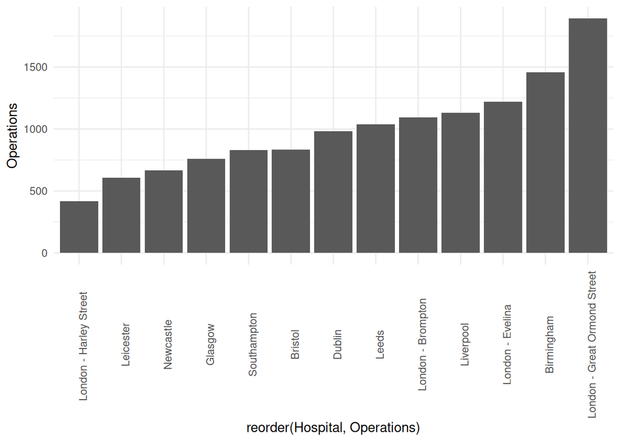

```r
fig5<- ggplot(data = HospitalData, mapping = aes(x = reorder(Hospital, Operations), y = Operations)) +
  theme_minimal() +
  theme(axis.text.x = element_text(angle = 90)) +
  geom_bar(stat = "identity")
fig5
```

```r
#Note: Here, it looks like from the examples, the closest one is rotating the x-axis text labels by 90 degrees using the native theme function. It says that “axis.text.x” is the argument, which makes sense, and then you just set the angle of the text to 90 degrees in the new line.
```

```r
### This chunk of code is for grading purposes.
### Don't change/delete this chunk of code.
q7 <- fig5
```

step 6 (1 point): It is really coming together! We are in the home stretch now! Since we reordered the x axis, the x axis label no longer looks good. Lets rename the X axis back to simply: “Hospital”. Copy the code you wrote in step 5 into the box below and add a new line that changes the x label. If lost, start here: http://www.sthda.com/english/wiki/ggplot2-title-main-axis-and-legend-titles

Check your fig 6 with the answer key and if they look identical, move on to step 7.

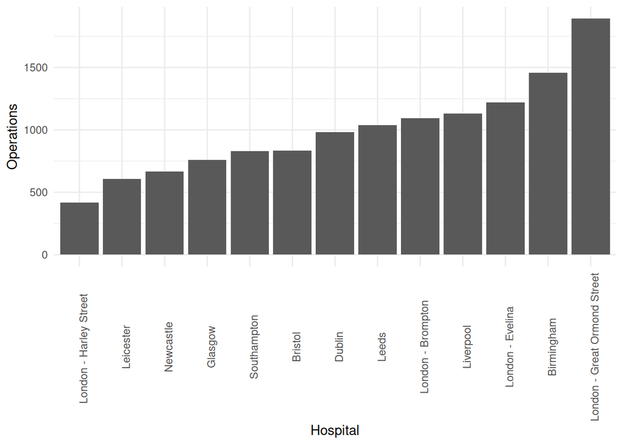

```r
fig6<- ggplot(data = HospitalData, mapping = aes(x = reorder(Hospital, Operations), y = Operations)) +
  theme_minimal() +
  theme(axis.text.x = element_text(angle = 90)) +
  xlab("Hospital") +
  geom_bar(stat = "identity")
fig6
```

```r
#Note: All you needed to do here was to add a line that relabels the x axis title to Hospital with the xlab() function from the documentation.
```

```r
### This chunk of code is for grading purposes.
### Don't change/delete this chunk of code.
q8 <- fig6
```

Step 7 (2 points): Now the big step. Copy your code from step 6 into the box below and once again add to the aes() function to add a gradient fill color to the bars associated with the survival rate you calculated in last week’s assignment. Check out how the “fill =” argument is used with a third data column here: https://r-graphics.org/recipe-bar-graph-colors

Check your fig 7 with the answer key and if they look identical, move on to step 8.

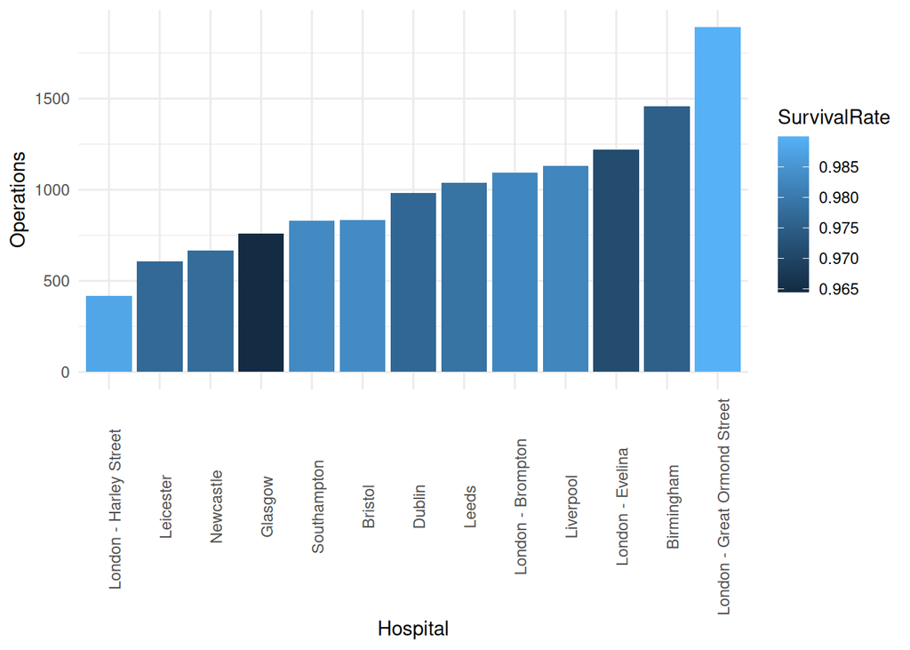

```r
fig7<- ggplot(data = HospitalData, mapping = aes(x = reorder(Hospital, Operations), y = Operations, fill = SurvivalRate)) +
  theme_minimal() +
  theme(axis.text.x = element_text(angle = 90)) +
  xlab("Hospital") +
  geom_bar(stat = "identity")
fig7
```

```r
#Note: Once again, all I needed to do here was add another argument to the aesthetic function called 'fill', and set/map the variable to the SurvivalRate vector column, and R handled the rest with a gradient legend.
```

```r
### This chunk of code is for grading purposes.
### Don't change/delete this chunk of code.
q9 <- fig7
```

step 8 (1 point): Now you have a pretty good looking plot! There is still plenty to learn and explore in ggplot but I think this is enough for one assignment! Now lets save this figure we made as an image file (a .tiff) using the ggsave function. Hint: the only three arguments in the ggsave function you need to assign today are the “filename =”, “plot =”, and “device =” arguments. You can leave the others as defaults. You can use `?ggsave` to get the help file for this function if you need it. Make sure you name the file as “Week3figure.tiff”.

```r
ggsave(
  "Week3figure.tiff",
  plot = last_plot(),
  device = "tiff"
)
# I ran the help function in my console, and it said I could simply call the ggsave function with the filename I needed -- in this case the Week3figure from the instructions, call the last plot made in the code, and the device is just the file extension, which is tiff.
```

```r
### This chunk of code is for grading purposes.
### Don't change/delete this chunk of code.
q10 <- file.exists("Week3figure.tiff")
```

Once you are done, click the “Knit” button above(It looks like a blue ball of yarn). Save the file with your name and the week number in the file name:

(for example: “DONE_Liam_Mueller_Problem_Set_3”).

Then upload the .rmd file to canvas under the Week 3 Section Assignment before the deadline.

And that is it for this week!